# Data Preparation - SILC

Joana Martins

2026-02-10

# Initial Processing of the Dataset

First step was reading the provided subset of SILC data.

```r
library(readxl)
SILC <- read_xlsx("C:/Users/PC/Documents/Estágio e Dissertação/SILC2.xlsx")

head(SILC)
```

```
## # A tibble: 6 × 27
##       RB030 PL051A PL145 HB130 PL040A  RB040 RB050 RB081 RB082 RB090 HB120 DB090
##       <dbl>  <dbl> <dbl> <dbl>  <dbl>  <dbl> <dbl> <dbl> <dbl> <dbl> <dbl> <dbl>
## 1 800190001     21     1     4      3 8.00e6  52.3    52    53     1     3  52.3
## 2 800450001     23    NA     4      3 8.00e6  94.0    43    43     2     4  94.0
## 3 801980001     31     1     4      3 8.02e6 224.     36    37     2     1 224.
## 4 802080003     52     1     4      2 8.02e6 269.     35    35     2     3 269.
## 5 802650001     25     1     4      3 8.03e6 132.     50    51     1     5 132.
## 6 802650002     NA    NA     4     NA 8.03e6 132.     51    51     2     5 132.
## # ℹ 15 more variables: DECILE <chr>, QUINTILE <chr>, RB280 <chr>, RB290 <chr>,
## #   PE041 <dbl>, PB190 <dbl>, PB200 <dbl>, RB211 <dbl>, HB110 <dbl>,
## #   HH021 <dbl>, HH030 <dbl>, PB205 <dbl>, PB230 <chr>, PB240 <chr>,
## #   PL032 <dbl>
```

Then, removed variables that won’t be used

```r
library(dplyr)
SILC <- SILC %>% select(-c(HB110, HH021, HH030, PB205, PB200, RB081
                           , DECILE, QUINTILE, PL032, PB190, PL051A))
```

For more intuitive understanding, renamed the variables

```r
names(SILC)[names(SILC) == "RB030"] <- "PersonalID"
names(SILC)[names(SILC) == "RB040"] <- "HhID"
names(SILC)[names(SILC) == "RB050"] <- "PersonalWeight"
names(SILC)[names(SILC) == "DB090"] <- "HhWeight"
names(SILC)[names(SILC) == "RB082"] <- "Age"
names(SILC)[names(SILC) == "RB090"] <- "Gender"
names(SILC)[names(SILC) == "HB120"] <- "HhSize"
names(SILC)[names(SILC) == "RB280"] <- "CountryBirth"
names(SILC)[names(SILC) == "RB290"] <- "Citizenship"
names(SILC)[names(SILC) == "PE041"] <- "EducationalLevel"
names(SILC)[names(SILC) == "RB211"] <- "ActivityStatus"
names(SILC)[names(SILC) == "PB230"] <- "FatherCountryBirth"
names(SILC)[names(SILC) == "PB240"] <- "MotherCountryBirth"
names(SILC)[names(SILC) == "PL145"] <- "FullPartTime"
names(SILC)[names(SILC) == "HB130"] <- "InterviewMode"
names(SILC)[names(SILC) == "PL040A"] <- "EmploymentStatus"
```

Multiply weights to match the whole population since we are only using a subset of SILC

```r
SILC <- SILC %>%
  mutate(PersonalWeight = PersonalWeight * (12871 / 5000))
```

# Inspection and Recoding of Variables

To match the formatting of GEM data, a comparative analysis was carried out prior to the descriptive documentation of the variables in each of the surveys in order to consider the best way to perform the matching.

## Age

```r
str(SILC$Age)
```

```
##  num [1:5000] 53 43 37 35 51 51 20 16 17 58 ...
```

```r
SILC <- SILC %>%
  mutate(Age = case_when(
    Age < 18 ~ "0-17",
    Age >= 18 & Age <= 24 ~ "18-24",
    Age >= 25 & Age <= 34 ~ "25-34",
    Age >= 35 & Age <= 44 ~ "35-44",
    Age >= 45 & Age <= 54 ~ "45-54",
    Age >= 55 & Age <= 64 ~ "55-64",
    Age >= 65 ~ "65+",
    TRUE ~ NA_character_
  ))

SILC$Age <- factor(SILC$Age,
                   levels = c("0-17","18-24","25-34","35-44","45-54","55-64","65+")
)

library(tibble)
age_distribution <- SILC %>%
  group_by(Age) %>%
  summarise(
    Count = n(),
    Weighted_Count = sum(PersonalWeight, na.rm = TRUE)
  ) %>%
  mutate(
    Percentage = round(Count / sum(Count) * 100, 1),
    Weighted_Percentage = round(Weighted_Count / sum(Weighted_Count) * 100, 1)
  )

age_distribution <- age_distribution %>%
  mutate(Age = as.character(Age)) %>%
  bind_rows(tibble(
    Age = "Total",
    Count = sum(.$Count),
    Weighted_Count = sum(.$Weighted_Count),
    Percentage = 100,
    Weighted_Percentage = 100
  ))

print(age_distribution)
```

```
## # A tibble: 8 × 5
##   Age   Count Weighted_Count Percentage Weighted_Percentage
##   <chr> <int>          <dbl>      <dbl>               <dbl>
## 1 0-17    950        133239.       19                  20.2
## 2 18-24   323         61183.        6.5                 9.3
## 3 25-34   592         96169.       11.8                14.6
## 4 35-44   783         97400.       15.7                14.7
## 5 45-54   730         90282.       14.6                13.7
## 6 55-64   755         87619.       15.1                13.3
## 7 65+     867         94527.       17.3                14.3
## 8 Total  5000        660419.      100                 100
```

```r
SILC <- SILC %>%
  filter(!(Age %in% c("0-17", "65+", "Missing")))

SILC$Age <- droplevels(SILC$Age)

age_distribution2 <- SILC %>%
  group_by(Age) %>%
  summarise(
    Count = n(),
    Weighted_Count = sum(PersonalWeight, na.rm = TRUE)
  ) %>%
  mutate(
    Percentage = round(Count / sum(Count) * 100, 1),
    Weighted_Percentage = round(Weighted_Count / sum(Weighted_Count) * 100, 1)
  )

age_distribution2 <- age_distribution2 %>%
  mutate(Age = as.character(Age)) %>%
  bind_rows(tibble(
    Age = "Total",
    Count = sum(.$Count),
    Weighted_Count = sum(.$Weighted_Count),
    Percentage = 100,
    Weighted_Percentage = 100
  ))

print(age_distribution2)
```

```
## # A tibble: 6 × 5
##   Age   Count Weighted_Count Percentage Weighted_Percentage
##   <chr> <int>          <dbl>      <dbl>               <dbl>
## 1 18-24   323         61183.       10.1                14.1
## 2 25-34   592         96169.       18.6                22.2
## 3 35-44   783         97400.       24.6                22.5
## 4 45-54   730         90282.       22.9                20.9
## 5 55-64   755         87619.       23.7                20.3
## 6 Total  3183        432653.      100                 100
```

## Gender

```r
str(SILC$Gender)
```

```
##  num [1:3183] 1 2 2 2 1 2 1 1 1 2 ...
```

```r
SILC %>%
  count(Gender)
```

```
## # A tibble: 2 × 2
##   Gender     n
##    <dbl> <int>
## 1      1  1575
## 2      2  1608
```

```r
SILC$Gender <- factor(SILC$Gender, levels = c(1, 2),
                      labels = c("Male", "Female"))

gender_distribution <- SILC %>%
  group_by(Gender) %>%
  summarise(
    Count = n(),
    Weighted_Count = sum(PersonalWeight, na.rm = TRUE)
  ) %>%
  mutate(
    Percentage = round(Count / sum(Count) * 100, 1),
    Weighted_Percentage = round(Weighted_Count / sum(Weighted_Count) * 100, 1)
  )

gender_distribution <- gender_distribution %>%
  mutate(Gender = as.character(Gender)) %>%
  bind_rows(tibble(
    Gender = "Total",
    Count = sum(.$Count),
    Weighted_Count = sum(.$Weighted_Count),
    Percentage = 100,
    Weighted_Percentage = 100
  ))

print(gender_distribution)
```

```
## # A tibble: 3 × 5
##   Gender Count Weighted_Count Percentage Weighted_Percentage
##   <chr>  <int>          <dbl>      <dbl>               <dbl>
## 1 Male    1575        217255.       49.5                50.2
## 2 Female  1608        215398.       50.5                49.8
## 3 Total   3183        432653.      100                 100
```

## Household size

```r
str(SILC$HhSize)
```

```
##  num [1:3183] 3 4 1 3 5 5 5 2 4 4 ...
```

```r
SILC %>%
  count(HhSize)
```

```
## # A tibble: 9 × 2
##   HhSize     n
##    <dbl> <int>
## 1      1   503
## 2      2   882
## 3      3   707
## 4      4   784
## 5      5   228
## 6      6    54
## 7      7    20
## 8      8     2
## 9     10     3
```

```r
SILC <- SILC %>%
  mutate(HhSize = case_when(
    HhSize == 1 ~ "1",
    HhSize == 2 ~ "2",
    HhSize >= 3 ~ "3+"
  ))

SILC$HhSize <- factor(SILC$HhSize,
                      levels = c("1", "2", "3+"))

hhsize_distribution <- SILC %>%
  group_by(HhSize) %>%
  summarise(
    Count = n(),
    Weighted_Count = sum(PersonalWeight, na.rm = TRUE)
  ) %>%
  mutate(
    Percentage = round(Count / sum(Count) * 100, 1),
    Weighted_Percentage = round(Weighted_Count / sum(Weighted_Count) * 100, 1)
  )

hhsize_distribution <- hhsize_distribution %>%
  mutate(HhSize = as.character(HhSize)) %>%
  bind_rows(tibble(
    HhSize = "Total",
    Count = sum(.$Count),
    Weighted_Count = sum(.$Weighted_Count),
    Percentage = 100,
    Weighted_Percentage = 100
  ))

print(hhsize_distribution)
```

```
## # A tibble: 4 × 5
##   HhSize Count Weighted_Count Percentage Weighted_Percentage
##   <chr>  <int>          <dbl>      <dbl>               <dbl>
## 1 1        503         70720.       15.8                16.3
## 2 2        882        100374.       27.7                23.2
## 3 3+      1798        261559.       56.5                60.5
## 4 Total   3183        432653.      100                 100
```

## Country of birth

```r
str(SILC$CountryBirth)
```

```
##  chr [1:3183] "FR" "CZ" "FR" "SK" "FR" "FR" "LU" "ES" "ES" "ES" "EL" "IT" ...
```

```r
library(countrycode)
SILC <- SILC %>%
  mutate(
    CountryBirth = case_when(
      CountryBirth == "EL" ~ "GR",
      CountryBirth == "UK" ~ "GB",
      TRUE ~ CountryBirth
    ),
    Continent = suppressWarnings(countrycode(CountryBirth, origin = "iso2c", destination = "continent")),
    CountryBirth = case_when(
      CountryBirth == "LU" ~ "Luxembourg",
      CountryBirth == "PT" ~ "Portugal",
      Continent == "Europe" | CountryBirth %in% c("XK", "GB") ~ "Other countries in Europe",
      (!is.na(Continent) & Continent != "Europe") | CountryBirth == "FOR" ~ "Rest of the World",
      TRUE ~ NA_character_
    )
  )

SILC$CountryBirth <- factor(SILC$CountryBirth,
  levels = c("Luxembourg", "Portugal", "Other countries in Europe", "Rest of the World")
)

countryb_distribution <- SILC %>%
  group_by(CountryBirth) %>%
  summarise(
    Count = n(),
    Weighted_Count = sum(PersonalWeight, na.rm = TRUE)
  ) %>%
  mutate(
    Percentage = round(Count / sum(Count) * 100, 1),
    Weighted_Percentage = round(Weighted_Count / sum(Weighted_Count) * 100, 1)
  )

countryb_distribution <- countryb_distribution %>%
  mutate(CountryBirth = as.character(CountryBirth)) %>%
  bind_rows(tibble(
    CountryBirth = "Total",
    Count = sum(.$Count),
    Weighted_Count = sum(.$Weighted_Count),
    Percentage = 100,
    Weighted_Percentage = 100
  ))

print(countryb_distribution)
```

```
## # A tibble: 5 × 5
##   CountryBirth              Count Weighted_Count Percentage Weighted_Percentage
##   <chr>                     <int>          <dbl>      <dbl>               <dbl>
## 1 Luxembourg                 1421        179155.       44.6                41.4
## 2 Portugal                    300         53573.        9.4                12.4
## 3 Other countries in Europe  1088        147959.       34.2                34.2
## 4 Rest of the World           374         51965.       11.7                12
## 5 Total                      3183        432653.      100                 100
```

## Parents’ country of birth

```r
SILC <- SILC %>%
  mutate(
    ParentsCountryBirth = case_when(
      FatherCountryBirth == "LU" & MotherCountryBirth == "LU" ~ "Luxembourg",
      FatherCountryBirth == "LU" & is.na(MotherCountryBirth) ~ NA_character_,
      is.na(FatherCountryBirth) & MotherCountryBirth == "LU" ~ NA_character_,
      is.na(FatherCountryBirth) & is.na(MotherCountryBirth) ~ NA_character_,
      TRUE ~ "Abroad"
    )
  )

SILC$ParentsCountryBirth <- factor(SILC$ParentsCountryBirth,
  levels = c("Luxembourg", "Abroad")
)

pcountryb_distribution <- SILC %>%
  group_by(ParentsCountryBirth) %>%
  summarise(
    Count = n(),
    Weighted_Count = sum(PersonalWeight, na.rm = TRUE)
  ) %>%
  mutate(
    Percentage = round(Count / sum(Count) * 100, 1),
    Weighted_Percentage = round(Weighted_Count / sum(Weighted_Count) * 100, 1)
  )

pcountryb_distribution <- pcountryb_distribution %>%
  mutate(ParentsCountryBirth = as.character(ParentsCountryBirth)) %>%
  bind_rows(tibble(
    ParentsCountryBirth = "Total",
    Count = sum(.$Count),
    Weighted_Count = sum(.$Weighted_Count),
    Percentage = 100,
    Weighted_Percentage = 100
  ))

print(pcountryb_distribution)
```

```
## # A tibble: 4 × 5
##   ParentsCountryBirth Count Weighted_Count Percentage Weighted_Percentage
##   <chr>               <int>          <dbl>      <dbl>               <dbl>
## 1 Luxembourg            861         98265.       27                  22.7
## 2 Abroad               2300        328492.       72.3                75.9
## 3 <NA>                   22          5896.        0.7                 1.4
## 4 Total                3183        432653.      100                 100
```

## Citizenship

Note: This variable was only included to help in the multiple imputation.

```r
SILC <- SILC %>%
  mutate(
    Citizenship = case_when(
      Citizenship == "EL" ~ "GR",
      Citizenship == "UK" ~ "GB",
      TRUE ~ Citizenship
    ),
    Continent = suppressWarnings(countrycode(Citizenship, origin = "iso2c", destination = "continent")),
    Citizenship = case_when(
      Citizenship == "LU" ~ "Luxembourg",
      Citizenship == "PT" ~ "Portugal",
      Continent == "Europe" | Citizenship %in% c("XK", "GB") ~ "Other countries in Europe",
      (!is.na(Continent) & Continent != "Europe") | Citizenship == "FOR" ~ "Rest of the World",
      TRUE ~ NA_character_
    )
  )

SILC$Citizenship <- factor(SILC$Citizenship,
  levels = c("Luxembourg", "Portugal", "Other countries in Europe", "Rest of the World")
)

citizenship_distribution <- SILC %>%
  group_by(Citizenship) %>%
  summarise(
    Count = n(),
    Weighted_Count = sum(PersonalWeight, na.rm = TRUE)
  ) %>%
  mutate(
    Percentage = round(Count / sum(Count) * 100, 1),
    Weighted_Percentage = round(Weighted_Count / sum(Weighted_Count) * 100, 1)
  )

citizenship_distribution <- citizenship_distribution %>%
  mutate(Citizenship = as.character(Citizenship)) %>%
  bind_rows(tibble(
    Citizenship = "Total",
    Count = sum(.$Count),
    Weighted_Count = sum(.$Weighted_Count),
    Percentage = 100,
    Weighted_Percentage = 100
  ))

print(citizenship_distribution)
```

```
## # A tibble: 6 × 5
##   Citizenship               Count Weighted_Count Percentage Weighted_Percentage
##   <chr>                     <int>          <dbl>      <dbl>               <dbl>
## 1 Luxembourg                 1737        220407.       54.6                50.9
## 2 Portugal                    316         53922.        9.9                12.5
## 3 Other countries in Europe   902        128399.       28.3                29.7
## 4 Rest of the World           198         26569.        6.2                 6.1
## 5 <NA>                         30          3355.        0.9                 0.8
## 6 Total                      3183        432653.      100                 100
```

## Educational level

```r
str(SILC$EducationalLevel)
```

```
##  num [1:3183] 700 800 700 700 700 590 354 700 700 700 ...
```

```r
SILC %>%
  count(EducationalLevel)
```

```
## # A tibble: 21 × 2
##    EducationalLevel     n
##               <dbl> <int>
##  1                0    97
##  2              100   154
##  3              200   157
##  4              340   119
##  5              343     1
##  6              344    43
##  7              350   492
##  8              353    96
##  9              354   212
## 10              390    16
## # ℹ 11 more rows
```

```r
SILC <- SILC %>%
  mutate(EducationalLevel = case_when(
    EducationalLevel %in% c("0", "000", "100", "200") ~ "Low",
    EducationalLevel %in% c("340", "342", "343", "344", "349", "350", "352",
                          "353", "354", "359", "390", "392", "393", "394",
                          "399", "440", "450", "490") ~ "Medium",
    EducationalLevel %in% c("540", "550", "590", "600", "700", "800") ~ "High",
    TRUE ~ NA_character_
  )) %>%
  mutate(EducationalLevel = factor(EducationalLevel, levels = c("Low", "Medium", "High")))

educ_distribution <- SILC %>%
  group_by(EducationalLevel) %>%
  summarise(
    Count = n(),
    Weighted_Count = sum(PersonalWeight, na.rm = TRUE)
  ) %>%
  mutate(
    Percentage = round(Count / sum(Count) * 100, 1),
    Weighted_Percentage = round(Weighted_Count / sum(Weighted_Count) * 100, 1)
  )

educ_distribution <- educ_distribution %>%
  mutate(EducationalLevel = as.character(EducationalLevel)) %>%
  bind_rows(tibble(
    EducationalLevel = "Total",
    Count = sum(.$Count),
    Weighted_Count = sum(.$Weighted_Count),
    Percentage = 100,
    Weighted_Percentage = 100
  ))

print(educ_distribution)
```

```
## # A tibble: 5 × 5
##   EducationalLevel Count Weighted_Count Percentage Weighted_Percentage
##   <chr>            <int>          <dbl>      <dbl>               <dbl>
## 1 Low                408         52304.       12.8                12.1
## 2 Medium            1035        145373.       32.5                33.6
## 3 High              1532        201076.       48.1                46.5
## 4 <NA>               208         33901.        6.5                 7.8
## 5 Total             3183        432653.      100                 100
```

## Activity status

```r
str(SILC$ActivityStatus)
```

```
##  num [1:3183] 1 1 1 1 1 6 5 1 1 1 ...
```

```r
SILC %>%
  count(ActivityStatus)
```

```
## # A tibble: 7 × 2
##   ActivityStatus     n
##            <dbl> <int>
## 1              1  2179
## 2              2   126
## 3              3   266
## 4              4    74
## 5              5   295
## 6              6   164
## 7              8    79
```

```r
SILC <- SILC %>%
  mutate( ActivityStatus = case_when(
      ActivityStatus == 1 ~ "Employed",
      ActivityStatus == 2 ~ "Unemployed",
      ActivityStatus == 3 ~ "Retired",
      ActivityStatus %in% c(4, 5, 6, 7, 8) ~ "Inactive",
      TRUE ~ NA_character_
    )
  )

SILC$ActivityStatus <- factor(SILC$ActivityStatus,
                                levels = c("Employed", "Unemployed", "Retired", "Inactive"))

active_distribution <- SILC %>%
  group_by(ActivityStatus) %>%
  summarise(
    Count = n(),
    Weighted_Count = sum(PersonalWeight, na.rm = TRUE)
  ) %>%
  mutate(
    Percentage = round(Count / sum(Count) * 100, 1),
    Weighted_Percentage = round(Weighted_Count / sum(Weighted_Count) * 100, 1)
  )

active_distribution <- active_distribution %>%
  mutate(ActivityStatus = as.character(ActivityStatus)) %>%
  bind_rows(tibble(
    ActivityStatus = "Total",
    Count = sum(.$Count),
    Weighted_Count = sum(.$Weighted_Count),
    Percentage = 100,
    Weighted_Percentage = 100
  ))

print(active_distribution)
```

```
## # A tibble: 5 × 5
##   ActivityStatus Count Weighted_Count Percentage Weighted_Percentage
##   <chr>          <int>          <dbl>      <dbl>               <dbl>
## 1 Employed        2179        299134.       68.5                69.1
## 2 Unemployed       126         16237.        4                   3.8
## 3 Retired          266         26901.        8.4                 6.2
## 4 Inactive         612         90381.       19.2                20.9
## 5 Total           3183        432653.      100                 100
```

## Employment Status

```r
str(SILC$EmploymentStatus)
```

```
##  num [1:3183] 3 3 3 2 3 NA NA 3 2 3 ...
```

```r
SILC %>%
  count(EmploymentStatus)
```

```
## # A tibble: 5 × 2
##   EmploymentStatus     n
##              <dbl> <int>
## 1                1    97
## 2                2   101
## 3                3  1979
## 4                4     2
## 5               NA  1004
```

```r
SILC <- SILC %>%
  mutate(
    EmploymentStatus = case_when(
      EmploymentStatus == 1 ~ "Self-employed",
      EmploymentStatus == 2 ~ "Self-employed",
      EmploymentStatus == 3 ~ "Employee",
      EmploymentStatus == 4 ~ "Employee",
      is.na(EmploymentStatus) & ActivityStatus != "Employed" ~ "Others",
      is.na(EmploymentStatus) & ActivityStatus == "Employed" ~ NA_character_,
      is.na(EmploymentStatus) & is.na(ActivityStatus) ~ NA_character_,
      TRUE ~ NA_character_
    ),
    EmploymentStatus = factor(EmploymentStatus,
                              levels = c("Self-employed",
                                         "Employee",
                                         "Others"))
  )

emp_distribution <- SILC %>%
  group_by(EmploymentStatus) %>%
  summarise(
    Count = n(),
    Weighted_Count = sum(PersonalWeight, na.rm = TRUE)
  ) %>%
  mutate(
    Percentage = round(Count / sum(Count) * 100, 1),
    Weighted_Percentage = round(Weighted_Count / sum(Weighted_Count) * 100, 1)
  )

emp_distribution <- emp_distribution %>%
  mutate(EmploymentStatus = as.character(EmploymentStatus)) %>%
  bind_rows(tibble(
    EmploymentStatus = "Total",
    Count = sum(.$Count),
    Weighted_Count = sum(.$Weighted_Count),
    Percentage = 100,
    Weighted_Percentage = 100
  ))

print(emp_distribution)
```

```
## # A tibble: 4 × 5
##   EmploymentStatus Count Weighted_Count Percentage Weighted_Percentage
##   <chr>            <int>          <dbl>      <dbl>               <dbl>
## 1 Self-employed      198         29913.        6.2                 6.9
## 2 Employee          1981        269221.       62.2                62.2
## 3 Others            1004        133519.       31.5                30.9
## 4 Total             3183        432653.      100                 100
```

```r
library(tidyr)
SILC %>%
  count(EmploymentStatus, ActivityStatus, wt = PersonalWeight, name = "weighted_n") %>%
  group_by(ActivityStatus) %>%
  mutate(percent = round(100 * weighted_n / sum(weighted_n), 2)) %>%
  ungroup() %>%
  select(EmploymentStatus, ActivityStatus, percent) %>%
  pivot_wider(
    names_from = ActivityStatus,
    values_from = percent,
    values_fill = 0
  )
```

```
## # A tibble: 3 × 5
##   EmploymentStatus Employed Unemployed Retired Inactive
##   <fct>               <dbl>      <dbl>   <dbl>    <dbl>
## 1 Self-employed          10          0       0        0
## 2 Employee               90          0       0        0
## 3 Others                  0        100     100      100
```

## Full or Part-time Job

```r
str(SILC$FullPartTime)
```

```
##  num [1:3183] 1 NA 1 1 1 NA NA 1 2 1 ...
```

```r
SILC %>%
  count(FullPartTime)
```

```
## # A tibble: 3 × 2
##   FullPartTime     n
##          <dbl> <int>
## 1            1  1757
## 2            2   375
## 3           NA  1051
```

```r
SILC <- SILC %>%
  mutate(
    FullPartTime = case_when(
      FullPartTime == 1 ~ "Full-time",
      FullPartTime == 2 ~ "Part-time",
      is.na(FullPartTime) & ActivityStatus != "Employed" ~ "Others",
      is.na(FullPartTime) & ActivityStatus == "Employed" ~ NA_character_,
      is.na(FullPartTime) & is.na(ActivityStatus) ~ NA_character_,
      TRUE ~ NA_character_
    ),
  )


SILC$FullPartTime = factor(SILC$FullPartTime,
                                levels = c("Full-time", "Part-time", "Others"))


full_distribution <- SILC %>%
  group_by(FullPartTime) %>%
  summarise(
    Count = n(),
    Weighted_Count = sum(PersonalWeight, na.rm = TRUE)
  ) %>%
  mutate(
    Percentage = round(Count / sum(Count) * 100, 1),
    Weighted_Percentage = round(Weighted_Count / sum(Weighted_Count) * 100, 1)
  )

full_distribution <- full_distribution %>%
  mutate(FullPartTime = as.character(FullPartTime)) %>%
  bind_rows(tibble(
    FullPartTime = "Total",
    Count = sum(.$Count),
    Weighted_Count = sum(.$Weighted_Count),
    Percentage = 100,
    Weighted_Percentage = 100
  ))

print(full_distribution)
```

```
## # A tibble: 5 × 5
##   FullPartTime Count Weighted_Count Percentage Weighted_Percentage
##   <chr>        <int>          <dbl>      <dbl>               <dbl>
## 1 Full-time     1757        249413.       55.2                57.6
## 2 Part-time      375         43603.       11.8                10.1
## 3 Others        1004        133519.       31.5                30.9
## 4 <NA>            47          6118.        1.5                 1.4
## 5 Total         3183        432653.      100                 100
```

## Interview mode used

```r
str(SILC$InterviewMode)
```

```
##  num [1:3183] 4 4 4 4 4 4 4 4 4 4 ...
```

```r
SILC %>%
  count(InterviewMode)
```

```
## # A tibble: 3 × 2
##   InterviewMode     n
##           <dbl> <int>
## 1             2   607
## 2             3   375
## 3             4  2201
```

```r
SILC <- SILC %>%
  mutate(
    InterviewMode = case_when(
      InterviewMode %in% c(1, 2, 3) ~ "Interviewer-based",
      InterviewMode == 4 ~ "Self-administered",
      TRUE ~ NA_character_
    ),
    InterviewMode = factor(InterviewMode,
                             levels = c("Interviewer-based", "Self-administered"))
  )

int_distribution <- SILC %>%
  group_by(InterviewMode) %>%
  summarise(
    Count = n(),
    Weighted_Count = sum(PersonalWeight, na.rm = TRUE)
  ) %>%
  mutate(
    Percentage = round(Count / sum(Count) * 100, 1),
    Weighted_Percentage = round(Weighted_Count / sum(Weighted_Count) * 100, 1)
  )

int_distribution <- int_distribution %>%
  mutate(InterviewMode = as.character(InterviewMode)) %>%
  bind_rows(tibble(
    InterviewMode = "Total",
    Count = sum(.$Count),
    Weighted_Count = sum(.$Weighted_Count),
    Percentage = 100,
    Weighted_Percentage = 100
  ))

print(int_distribution)
```

```
## # A tibble: 3 × 5
##   InterviewMode     Count Weighted_Count Percentage Weighted_Percentage
##   <chr>             <int>          <dbl>      <dbl>               <dbl>
## 1 Interviewer-based   982         79197.       30.9                18.3
## 2 Self-administered  2201        353456.       69.1                81.7
## 3 Total              3183        432653.      100                 100
```

Removing auxiliary variables that won’t be needed further

```r
SILC <- SILC %>%
  select(-c("FatherCountryBirth",
            "MotherCountryBirth",
            "Continent"))
```

# Missing values

## Analysis of nature of the missing values

```r
library(mice)
```

```r
data_to_imp <- SILC %>%
  select(
    Age,
    Gender,
    CountryBirth,
    Citizenship,
    ParentsCountryBirth,,
    EducationalLevel,
    FullPartTime,
    ActivityStatus,
    EmploymentStatus
  )

print(md.pattern(data_to_imp, plot = FALSE))
```

```
##      Age Gender CountryBirth ActivityStatus EmploymentStatus
## 2919   1      1            1              1                1
## 177    1      1            1              1                1
## 27     1      1            1              1                1
## 11     1      1            1              1                1
## 11     1      1            1              1                1
## 11     1      1            1              1                1
## 3      1      1            1              1                1
## 2      1      1            1              1                1
## 14     1      1            1              1                1
## 4      1      1            1              1                1
## 1      1      1            1              1                1
## 1      1      1            1              1                1
## 2      1      1            1              1                1
##        0      0            0              0                0
##      ParentsCountryBirth Citizenship FullPartTime EducationalLevel
## 2919                   1           1            1                1   0
## 177                    1           1            1                0   1
## 27                     1           1            0                1   1
## 11                     1           1            0                0   2
## 11                     1           0            1                1   1
## 11                     1           0            1                0   2
## 3                      1           0            0                1   2
## 2                      1           0            0                0   3
## 14                     0           1            1                1   1
## 4                      0           1            1                0   2
## 1                      0           1            0                0   3
## 1                      0           0            0                1   3
## 2                      0           0            0                0   4
##                       22          30           47              208 307
```

```r
library(naniar)
mcar_test(data_to_imp)
```

```
## # A tibble: 1 × 4
##   statistic    df  p.value missing.patterns
##       <dbl> <dbl>    <dbl>            <int>
## 1      197.    83 2.91e-11               13
```

The result obtained (p < 0.001) allowed us to reject the hypothesis that the data are missing completely at random (MCAR).

Missing indicator variables were created for each of the incomplete variables, and logistic regression models were estimated.

```r
library(brglm2)
vars_with_missing <- c("ParentsCountryBirth",
                       "EducationalLevel",
                       "Citizenship",
                       "FullPartTime")

for(v in vars_with_missing){
  SILC[[paste0("miss_", v)]] <- as.numeric(is.na(SILC[[v]]))
}


predictors <- c("Age", "Gender", "CountryBirth",
                "EmploymentStatus", "ActivityStatus",
                "HhSize")


models <- list()

for(v in vars_with_missing){
  formula <- as.formula(
    paste0("miss_", v, " ~ ", paste(predictors, collapse = " + "))
  )

  models[[v]] <- glm(formula,
                     data = SILC,
                     family = binomial,
                     method = "brglmFit")

  cat("\n\n----------------------------------\n")
  cat(" Missingness model for:", v, "\n")
  cat("----------------------------------\n")
  print(summary(models[[v]]))
}
```

```
##
##
## ----------------------------------
##  Missingness model for: ParentsCountryBirth
## ----------------------------------
##
## Call:
## glm(formula = formula, family = binomial, data = SILC, method = "brglmFit")
##
## Deviance Residuals:
##     Min       1Q   Median       3Q      Max
## -0.5529  -0.1455  -0.0864  -0.0575   3.6298
##
## Coefficients: (1 not defined because of singularities)
##                                       Estimate Std. Error z value Pr(>|z|)
## (Intercept)                            -1.8595     0.8677  -2.143 0.032114 *
## Age25-34                               -0.4196     0.6817  -0.616 0.538188
## Age35-44                               -1.0076     0.6973  -1.445 0.148491
## Age45-54                               -1.2349     0.7011  -1.761 0.078184 .
## Age55-64                               -2.3096     0.9294  -2.485 0.012952 *
## GenderFemale                            0.4781     0.3869   1.235 0.216646
## CountryBirthPortugal                    1.0017     0.5938   1.687 0.091623 .
## CountryBirthOther countries in Europe   0.4668     0.4385   1.064 0.287110
## CountryBirthRest of the World          -0.4103     0.8078  -0.508 0.611479
## EmploymentStatusEmployee               -1.3188     0.5851  -2.254 0.024203 *
## EmploymentStatusOthers                 -0.2586     0.7097  -0.364 0.715616
## ActivityStatusUnemployed               -1.1522     1.3877  -0.830 0.406355
## ActivityStatusRetired                  -0.9482     1.5636  -0.606 0.544253
## ActivityStatusInactive                      NA         NA      NA       NA
## HhSize2                                -2.7662     0.7740  -3.574 0.000352 ***
## HhSize3+                               -1.9901     0.4758  -4.183 2.88e-05 ***
## ---
## Signif. codes:  0 '***' 0.001 '**' 0.01 '*' 0.05 '.' 0.1 ' ' 1
##
## (Dispersion parameter for binomial family taken to be 1)
##
##     Null deviance: 262.74  on 3182  degrees of freedom
## Residual deviance: 227.02  on 3168  degrees of freedom
## AIC:  257.02
##
```

[output cut: 113 more lines]

```
## ActivityStatusRetired                  1.498561   1.972301   0.760 0.447372
## ActivityStatusInactive                       NA         NA      NA       NA
## HhSize2                                0.007007   0.486008   0.014 0.988498
## HhSize3+                               0.491089   0.424259   1.158 0.247059
## ---
## Signif. codes:  0 '***' 0.001 '**' 0.01 '*' 0.05 '.' 0.1 ' ' 1
##
## (Dispersion parameter for binomial family taken to be 1)
##
##     Null deviance: 489.56  on 3182  degrees of freedom
## Residual deviance: 433.72  on 3168  degrees of freedom
## AIC:  463.72
##
## Type of estimator: AS_mixed (mixed bias-reducing adjusted score equations)
## Number of Fisher Scoring iterations: 9
```

## Imputation using MICE

For the imputation model, - **m = 30** is a conservative and stable choice when several variables have moderate missingness; it increases the accuracy of quantities derived from imputations (lower Monte Carlo variance) compared to minimum values (e.g., m=5). - **maxit = 15** is sufficient for convergence in the chains (verified via trace/strip plots). seed ensures reproducibility.

```r
ini  <- mice(data_to_imp, maxit = 0, printFlag = FALSE)
meth <- ini$method
pred <- ini$predictorMatrix

meth[] <- ""
meth["EducationalLevel"]    <- "polr"
meth["ParentsCountryBirth"]  <- "logreg"
meth["Citizenship"]         <- "polyreg"
meth["FullPartTime"]        <- "polyreg"

diag(pred) <- 0

visit <- c("Citizenship", "ParentsCountryBirth",
           "FullPartTime", "EducationalLevel")

imp_model <- mice(
  data_to_imp,
  m = 30,
  maxit = 15,
  method = meth,
  predictorMatrix = pred,
  visitSequence = visit,
  seed = 20260212,
  printFlag = FALSE
)
```

## Evaluation of the results of imputation

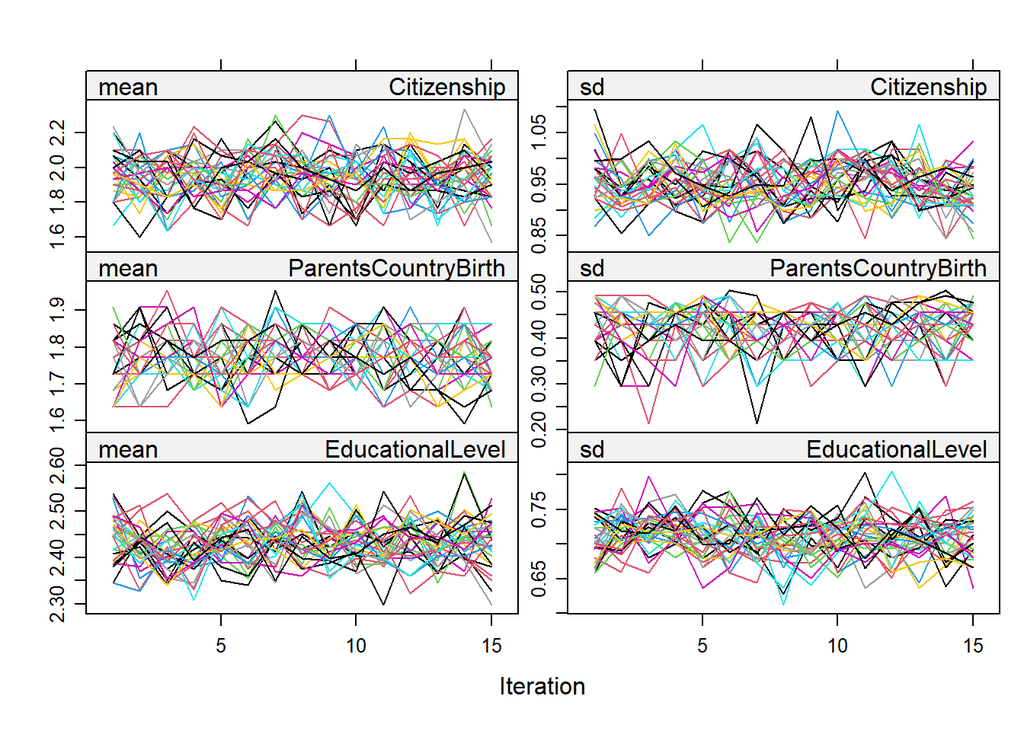

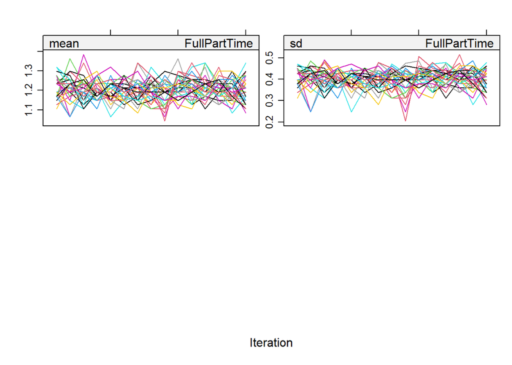

```r
plot(imp_model)
```

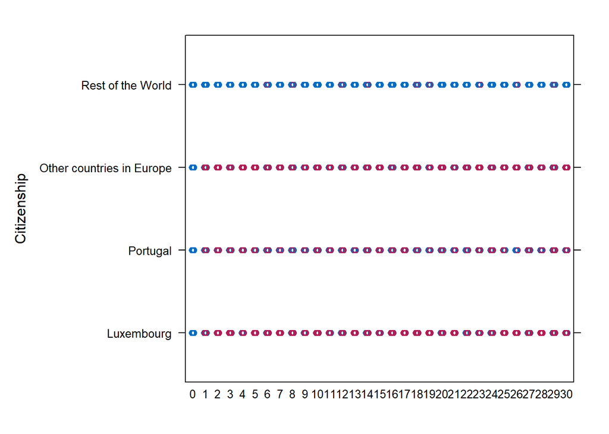

```r
stripplot(imp_model, Citizenship)
```

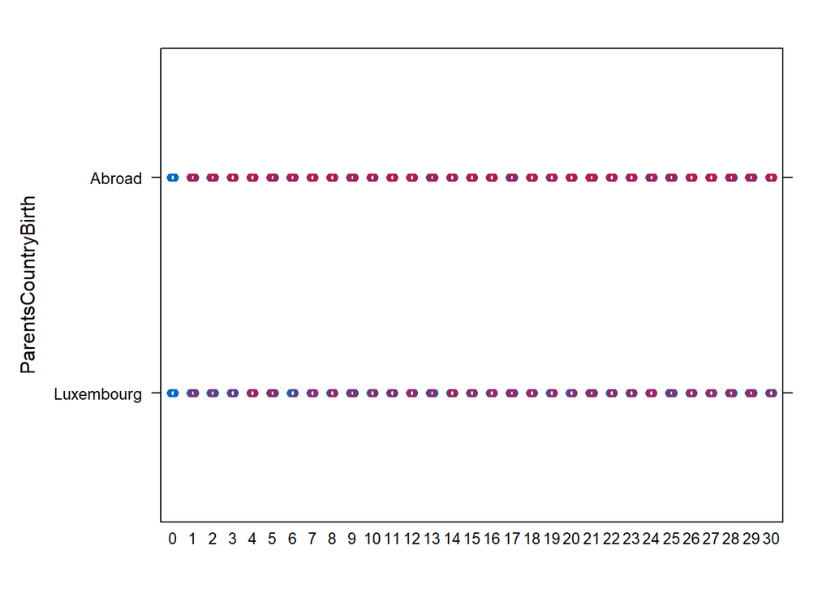

```r
stripplot(imp_model, ParentsCountryBirth)
```

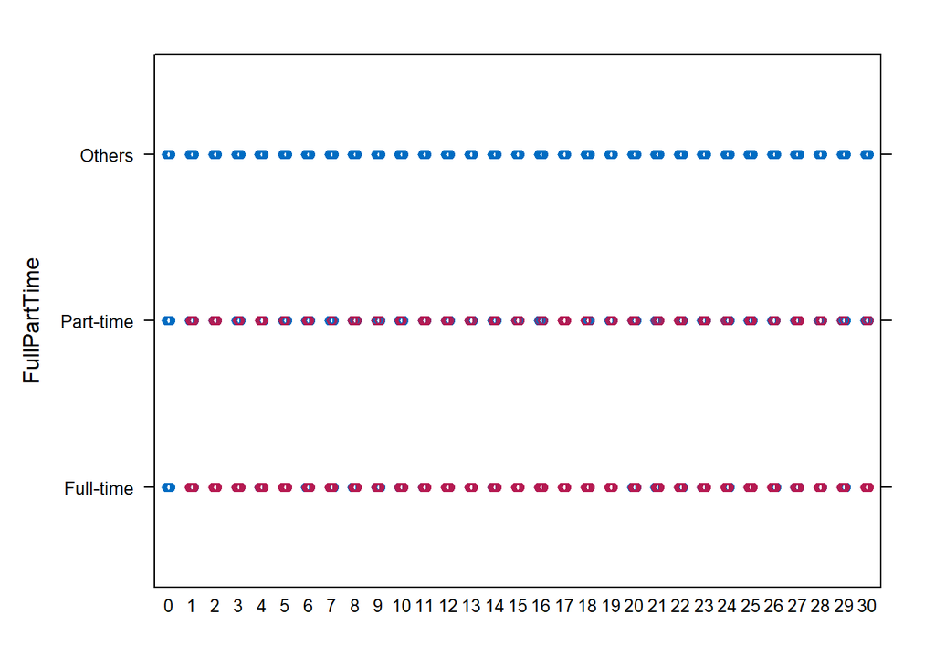

```r
stripplot(imp_model, FullPartTime)
```

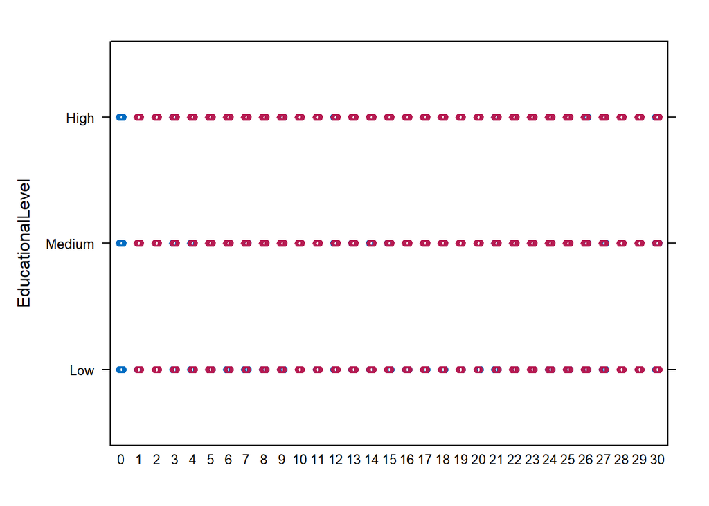

```r
stripplot(imp_model, EducationalLevel)
```

```r
set.seed(42)
completed_data <- complete(imp_model, sample(1:imp_model$m, 1))
```

```r
compare_tables <- function(original, imputed, varname) {
  cat("\n==============================\n")
  cat(varname, "\n")
  cat("Original:\n")
  print(table(original, useNA = "always"))
  cat("\nImputed:\n")
  print(table(imputed, useNA = "always"))
  cat("==============================\n\n")
}

compare_tables(SILC$EducationalLevel, completed_data$EducationalLevel, "EducationalLevel")
```

```
##
## ==============================
## EducationalLevel
## Original:
## original
##    Low Medium   High   <NA>
##    408   1035   1532    208
##
## Imputed:
## imputed
##    Low Medium   High   <NA>
##    431   1101   1651      0
## ==============================
```

```r
compare_tables(SILC$ParentsCountryBirth, completed_data$ParentsCountryBirth, "MotherCountryBirth")
```

```
##
## ==============================
## MotherCountryBirth
## Original:
## original
## Luxembourg     Abroad       <NA>
##        861       2300         22
##
## Imputed:
## imputed
## Luxembourg     Abroad       <NA>
##        866       2317          0
## ==============================
```

```r
compare_tables(SILC$FullPartTime, completed_data$FullPartTime, "FullPartTime")
```

```
##
## ==============================
## FullPartTime
## Original:
## original
## Full-time Part-time    Others      <NA>
##      1757       375      1004        47
##
## Imputed:
## imputed
## Full-time Part-time    Others      <NA>
##      1793       386      1004         0
## ==============================
```

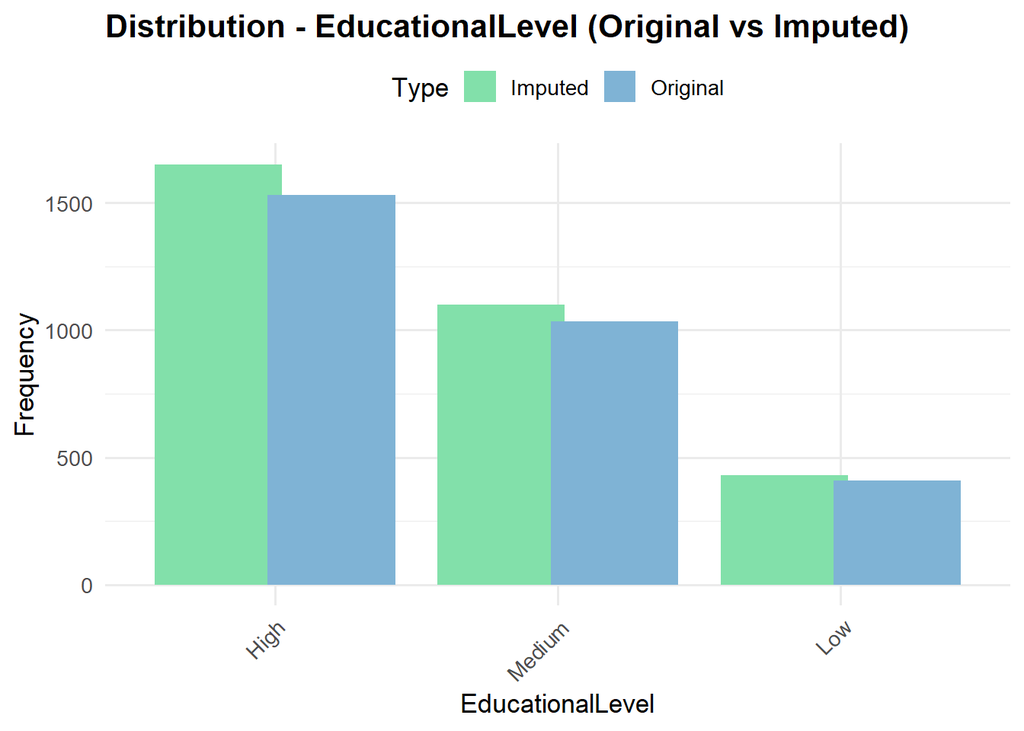

```r
library(ggplot2)
plot_compare <- function(original, imputed, varname, drop_na = TRUE, top_n = NULL) {
  df <- bind_rows(
    data.frame(Category = as.character(original), Type = "Original"),
    data.frame(Category = as.character(imputed),  Type = "Imputed")
  )

  if (drop_na) {
    df <- df |> filter(!is.na(Category))
  }

  df <- df |>
    mutate(Category = forcats::fct_infreq(Category))

  ggplot(df, aes(x = Category, fill = Type)) +
    geom_bar(position = position_dodge(width = 0.8)) +
    labs(
      title = paste("Distribution -", varname, "(Original vs Imputed)"),
      x = varname,
      y = "Frequency"
    ) +
    scale_fill_manual(values = c("Original" = "#7FB3D5", "Imputed" = "#82E0AA")) +
    theme_minimal(base_size = 13) +
    theme(
      axis.text.x = element_text(angle = 45, hjust = 1),
      legend.position = "top",
      plot.title = element_text(face = "bold")
    )
}

plot_compare(SILC$EducationalLevel,   completed_data$EducationalLevel,   "EducationalLevel", top_n = 10)
```

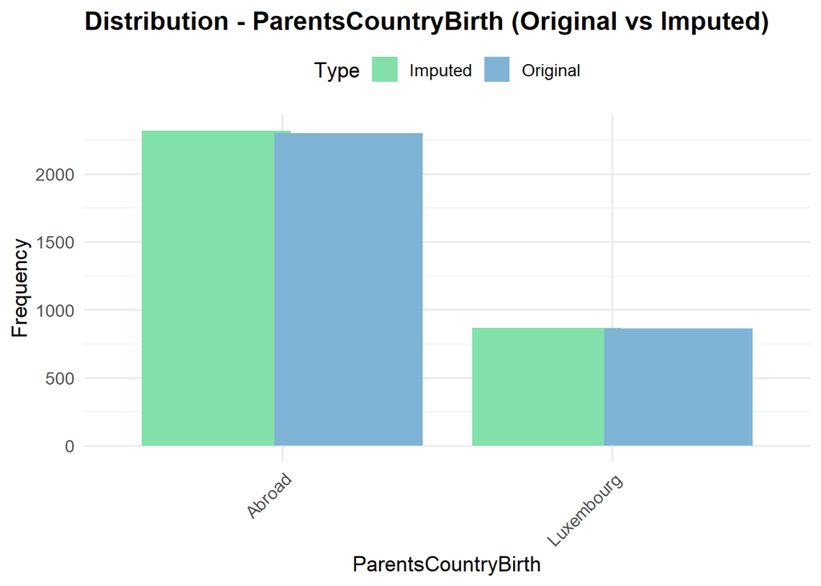

```r
plot_compare(SILC$ParentsCountryBirth, completed_data$ParentsCountryBirth, "ParentsCountryBirth", top_n = 10)
```

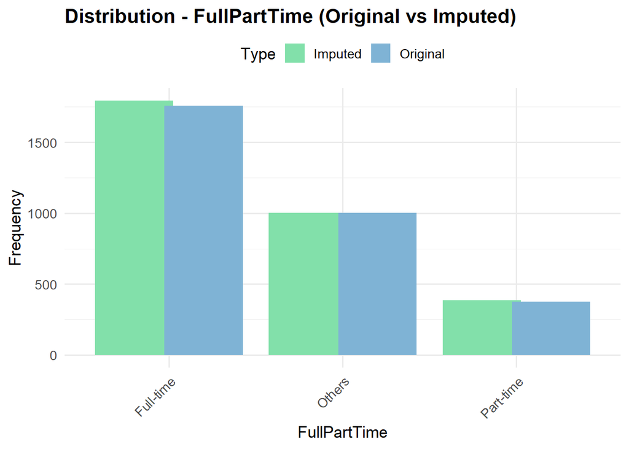

```r
plot_compare(SILC$FullPartTime,       completed_data$FullPartTime,       "FullPartTime", top_n = 10)
```

Since the imputations look OK, we can replace the variables in the SILC dataset.

```r
SILC$EducationalLevel <- completed_data$EducationalLevel
SILC$ParentsCountryBirth <- completed_data$ParentsCountryBirth
SILC$FullPartTime <- completed_data$FullPartTime
```

Removing auxiliary variables for MICE.

```r
SILC <- SILC %>%
  select(-c("miss_ParentsCountryBirth",
         "miss_EducationalLevel",
         "miss_Citizenship",
         "miss_FullPartTime",
         "Citizenship"))
```

# Overview of the final dataset

```r
str(SILC)
```

```
## tibble [3,183 × 14] (S3: tbl_df/tbl/data.frame)
##  $ PersonalID         : num [1:3183] 8.00e+08 8.00e+08 8.02e+08 8.02e+08 8.03e+08 ...
##  $ FullPartTime       : Factor w/ 3 levels "Full-time","Part-time",..: 1 1 1 1 1 3 3 1 2 1 ...
##  $ InterviewMode      : Factor w/ 2 levels "Interviewer-based",..: 2 2 2 2 2 2 2 2 2 2 ...
##  $ EmploymentStatus   : Factor w/ 3 levels "Self-employed",..: 2 2 2 1 2 3 3 2 1 2 ...
##  $ HhID               : num [1:3183] 8001900 8004500 8019800 8020800 8026500 ...
##  $ PersonalWeight     : num [1:3183] 135 242 577 693 339 ...
##  $ Age                : Factor w/ 5 levels "18-24","25-34",..: 4 3 3 3 4 4 1 5 4 4 ...
##  $ Gender             : Factor w/ 2 levels "Male","Female": 1 2 2 2 1 2 1 1 1 2 ...
##  $ HhSize             : Factor w/ 3 levels "1","2","3+": 3 3 1 3 3 3 3 2 3 3 ...
##  $ HhWeight           : num [1:3183] 52.3 94 224 269.2 131.9 ...
##  $ CountryBirth       : Factor w/ 4 levels "Luxembourg","Portugal",..: 3 3 3 3 3 3 1 3 3 3 ...
##  $ EducationalLevel   : Factor w/ 3 levels "Low","Medium",..: 3 3 3 3 3 3 2 3 3 3 ...
##  $ ActivityStatus     : Factor w/ 4 levels "Employed","Unemployed",..: 1 1 1 1 1 4 4 1 1 1 ...
##  $ ParentsCountryBirth: Factor w/ 2 levels "Luxembourg","Abroad": 2 2 2 2 2 2 2 2 2 2 ...
```

Statistics

```r
summary(SILC)
```

```
##    PersonalID           FullPartTime            InterviewMode
##  Min.   :8.002e+08   Full-time:1793   Interviewer-based: 982
##  1st Qu.:2.015e+09   Part-time: 386   Self-administered:2201
##  Median :3.013e+09   Others   :1004
##  Mean   :2.379e+09
##  3rd Qu.:3.083e+09
##  Max.   :3.150e+09
##       EmploymentStatus      HhID          PersonalWeight        Age
##  Self-employed: 198    Min.   : 8001900   Min.   :   1.147   18-24:323
##  Employee     :1981    1st Qu.:20152500   1st Qu.:  54.364   25-34:592
##  Others       :1004    Median :30129100   Median :  83.860   35-44:783
##                        Mean   :23789829   Mean   : 135.926   45-54:730
##                        3rd Qu.:30827400   3rd Qu.: 135.288   55-64:755
##                        Max.   :31499800   Max.   :4172.597
##     Gender     HhSize       HhWeight                            CountryBirth
##  Male  :1575   1 : 503   Min.   :   0.4454   Luxembourg               :1421
##  Female:1608   2 : 882   1st Qu.:  21.1187   Portugal                 : 300
##                3+:1798   Median :  32.5772   Other countries in Europe:1088
##                          Mean   :  52.8033   Rest of the World        : 374
##                          3rd Qu.:  52.5553
##                          Max.   :1620.9296
##  EducationalLevel    ActivityStatus ParentsCountryBirth
##  Low   : 431      Employed  :2179   Luxembourg: 866
##  Medium:1101      Unemployed: 126   Abroad    :2317
##  High  :1651      Retired   : 266
##                   Inactive  : 612
##
##
```

```r
library(DataExplorer)
```

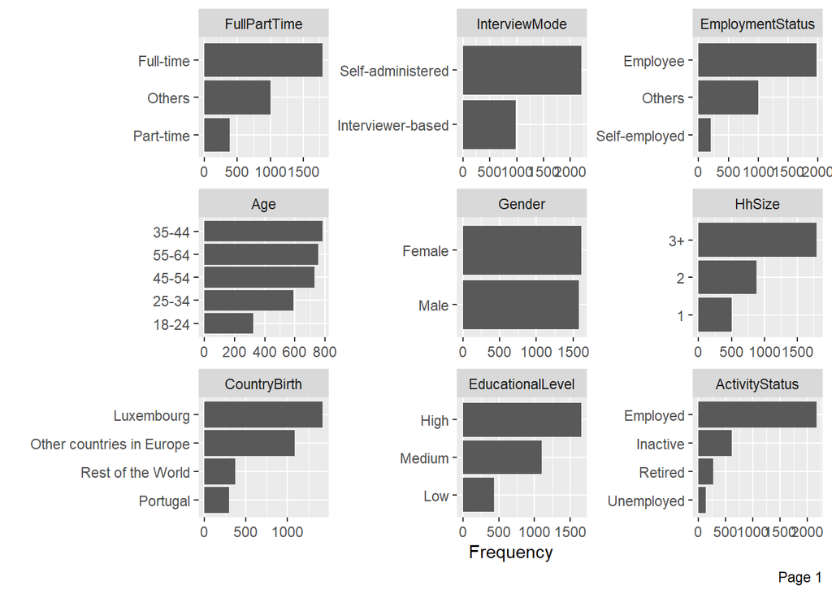

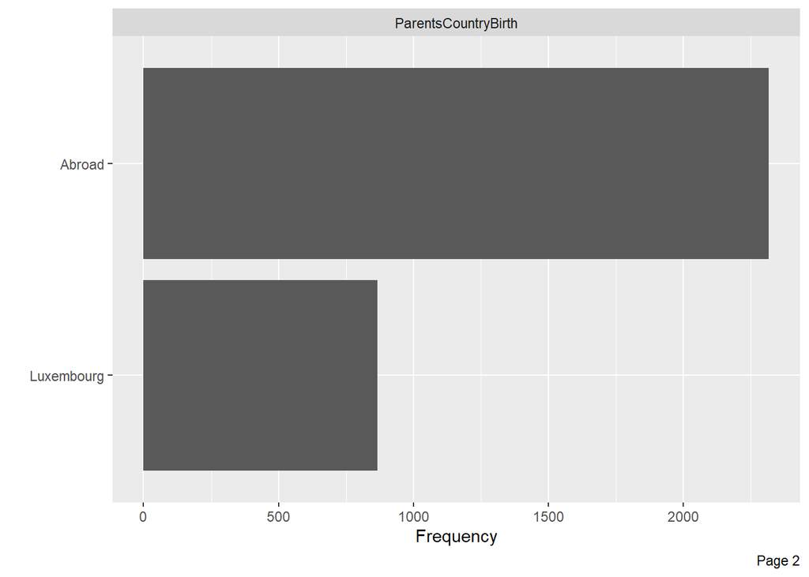

```r
plot_bar(SILC)
```

# Save final dataset

```r
library(writexl)
write_xlsx(SILC, "SILC_Final.xlsx")

getwd()
```

```
## [1] "C:/Users/PC/Downloads"
```